# EXPLORATORY DATA ANALYSIS FOR DIFFERENT USAGE OF MOBILE HEALTH APPLICATION

## Importing Libraries

```python
import pandas as pd
from pandas import Series, DataFrame
import numpy as np
import matplotlib.pyplot as plt
import seaborn as sns
sns.set(style='white',color_codes=True)
%matplotlib inline
import matplotlib.collections as mcol
from matplotlib.legend_handler import HandlerLineCollection, HandlerTuple
from matplotlib.lines import Line2D
```

## Reading the Dataset

```python
#Read in the dataset
df1 = pd.read_csv('C:/datasets/mHealth.csv', encoding = 'latin1')
#Latin 1 encoding is to interpret special character, to read in the file without producing error
df1
```

|  | MID | DAY | SEX | AGE | GEN | PRE | ARE | JOB | MAR | CHI | ... | q4s7 | q4s8 | q4s9 | q4s10 | q4s11 | q4s12 | q4s13 | q4s14 | q4s15 | q5 |
| --- | --- | --- | --- | --- | --- | --- | --- | --- | --- | --- | --- | --- | --- | --- | --- | --- | --- | --- | --- | --- | --- |
| 0 | NaN | NaN | NaN | NaN | NaN | NaN | NaN | NaN | NaN | NaN | ... | NaN | NaN | NaN | NaN | NaN | NaN | NaN | NaN | NaN | NaN |
| 1 | 1.000003e+09 | 6/8/2022 20:58 | 2.0 | 56.0 | 6.0 | 14.0 | 3.0 | 8.0 | 2.0 | 1.0 | ... | 4.0 | 3.0 | 3.0 | 3.0 | 4.0 | 3.0 | 3.0 | 3.0 | 3.0 | 3.0 |
| 2 | NaN | NaN | NaN | NaN | NaN | NaN | NaN | NaN | NaN | NaN | ... | NaN | NaN | NaN | NaN | NaN | NaN | NaN | NaN | NaN | NaN |
| 3 | 1.000004e+09 | 6/8/2022 22:17 | 1.0 | 64.0 | 7.0 | 13.0 | 3.0 | 6.0 | 2.0 | 1.0 | ... | 3.0 | 3.0 | 3.0 | 3.0 | 3.0 | 3.0 | 3.0 | 3.0 | 3.0 | 3.0 |
| 4 | NaN | NaN | NaN | NaN | NaN | NaN | NaN | NaN | NaN | NaN | ... | NaN | NaN | NaN | NaN | NaN | NaN | NaN | NaN | NaN | NaN |
| ... | ... | ... | ... | ... | ... | ... | ... | ... | ... | ... | ... | ... | ... | ... | ... | ... | ... | ... | ... | ... | ... |
| 1677 | 1.010023e+09 | 6/8/2022 19:31 | 2.0 | 42.0 | 5.0 | 23.0 | 4.0 | 9.0 | 1.0 | 2.0 | ... | 5.0 | 5.0 | 5.0 | 5.0 | 2.0 | 5.0 | 5.0 | 5.0 | 5.0 | 3.0 |
| 1678 | NaN | NaN | NaN | NaN | NaN | NaN | NaN | NaN | NaN | NaN | ... | NaN | NaN | NaN | NaN | NaN | NaN | NaN | NaN | NaN | NaN |
| 1679 | 1.010023e+09 | 6/8/2022 19:20 | 2.0 | 48.0 | 5.0 | 3.0 | 2.0 | 3.0 | 2.0 | 1.0 | ... | 2.0 | 2.0 | 2.0 | 2.0 | 2.0 | 3.0 | 2.0 | 2.0 | 3.0 | 3.0 |
| 1680 | NaN | NaN | NaN | NaN | NaN | NaN | NaN | NaN | NaN | NaN | ... | NaN | NaN | NaN | NaN | NaN | NaN | NaN | NaN | NaN | NaN |
| 1681 | 1.010036e+09 | 6/8/2022 19:13 | 1.0 | 47.0 | 5.0 | 42.0 | 8.0 | 4.0 | 2.0 | 1.0 | ... | 2.0 | 3.0 | 3.0 | 2.0 | 1.0 | 3.0 | 3.0 | 2.0 | 2.0 | 3.0 |

1682 rows × 33 columns

```python
df2 = df1.drop("q3t6", axis=1)#Drop"q3t6" column from the dataframe
print (df2.count())#Returns the number of non null values in each data frame column
```

```
MID      841
DAY      841
SEX      841
AGE      841
GEN      841
PRE      841
ARE      841
JOB      841
MAR      841
CHI      841
q1t1     413
q2c1     841
q2c2     841
q2c3     841
q2c4     841
q3       632
q4s1     632
q4s2     632
q4s3     632
q4s4     632
q4s5     632
q4s6     632
q4s7     632
q4s8     632
q4s9     632
q4s10    632
q4s11    632
q4s12    632
q4s13    632
q4s14    632
q4s15    632
q5       632
dtype: int64
```

```python
df2.head() #Display the first five rows in the dataset
```

|  | MID | DAY | SEX | AGE | GEN | PRE | ARE | JOB | MAR | CHI | ... | q4s7 | q4s8 | q4s9 | q4s10 | q4s11 | q4s12 | q4s13 | q4s14 | q4s15 | q5 |
| --- | --- | --- | --- | --- | --- | --- | --- | --- | --- | --- | --- | --- | --- | --- | --- | --- | --- | --- | --- | --- | --- |
| 0 | NaN | NaN | NaN | NaN | NaN | NaN | NaN | NaN | NaN | NaN | ... | NaN | NaN | NaN | NaN | NaN | NaN | NaN | NaN | NaN | NaN |
| 1 | 1.000003e+09 | 6/8/2022 20:58 | 2.0 | 56.0 | 6.0 | 14.0 | 3.0 | 8.0 | 2.0 | 1.0 | ... | 4.0 | 3.0 | 3.0 | 3.0 | 4.0 | 3.0 | 3.0 | 3.0 | 3.0 | 3.0 |
| 2 | NaN | NaN | NaN | NaN | NaN | NaN | NaN | NaN | NaN | NaN | ... | NaN | NaN | NaN | NaN | NaN | NaN | NaN | NaN | NaN | NaN |
| 3 | 1.000004e+09 | 6/8/2022 22:17 | 1.0 | 64.0 | 7.0 | 13.0 | 3.0 | 6.0 | 2.0 | 1.0 | ... | 3.0 | 3.0 | 3.0 | 3.0 | 3.0 | 3.0 | 3.0 | 3.0 | 3.0 | 3.0 |
| 4 | NaN | NaN | NaN | NaN | NaN | NaN | NaN | NaN | NaN | NaN | ... | NaN | NaN | NaN | NaN | NaN | NaN | NaN | NaN | NaN | NaN |

5 rows × 32 columns

## Data Cleaning

```python
#To drop duplicate value
df2 = df2.drop_duplicates()
df2.info()#Summary of a ssdataframe(total number of rows in the dataset, names of the columns, their datatype, and any missing value.)
```

```
<class 'pandas.core.frame.DataFrame'>
Int64Index: 842 entries, 0 to 1681
Data columns (total 32 columns):
MID      841 non-null float64
DAY      841 non-null object
SEX      841 non-null float64
AGE      841 non-null float64
GEN      841 non-null float64
PRE      841 non-null float64
ARE      841 non-null float64
JOB      841 non-null float64
MAR      841 non-null float64
CHI      841 non-null float64
q1t1     413 non-null object
q2c1     841 non-null float64
q2c2     841 non-null float64
q2c3     841 non-null float64
q2c4     841 non-null float64
q3       632 non-null float64
q4s1     632 non-null float64
q4s2     632 non-null float64
q4s3     632 non-null float64
q4s4     632 non-null float64
q4s5     632 non-null float64
q4s6     632 non-null float64
q4s7     632 non-null float64
q4s8     632 non-null float64
q4s9     632 non-null float64
q4s10    632 non-null float64
q4s11    632 non-null float64
q4s12    632 non-null float64
q4s13    632 non-null float64
q4s14    632 non-null float64
q4s15    632 non-null float64
q5       632 non-null float64
dtypes: float64(30), object(2)
memory usage: 217.1+ KB
```

```python
# To drop all rows that are completely empty
df= df2.dropna()
```

```python
df.info()
```

```
<class 'pandas.core.frame.DataFrame'>
Int64Index: 368 entries, 1 to 1681
Data columns (total 32 columns):
MID      368 non-null float64
DAY      368 non-null object
SEX      368 non-null float64
AGE      368 non-null float64
GEN      368 non-null float64
PRE      368 non-null float64
ARE      368 non-null float64
JOB      368 non-null float64
MAR      368 non-null float64
CHI      368 non-null float64
q1t1     368 non-null object
q2c1     368 non-null float64
q2c2     368 non-null float64
q2c3     368 non-null float64
q2c4     368 non-null float64
q3       368 non-null float64
q4s1     368 non-null float64
q4s2     368 non-null float64
q4s3     368 non-null float64
q4s4     368 non-null float64
q4s5     368 non-null float64
q4s6     368 non-null float64
q4s7     368 non-null float64
q4s8     368 non-null float64
q4s9     368 non-null float64
q4s10    368 non-null float64
q4s11    368 non-null float64
q4s12    368 non-null float64
q4s13    368 non-null float64
q4s14    368 non-null float64
q4s15    368 non-null float64
q5       368 non-null float64
dtypes: float64(30), object(2)
memory usage: 94.9+ KB
```

```python
#Analyzing String Pattern Only
df.describe(include=[np.object])
```

|  | DAY | q1t1 |
| --- | --- | --- |
| count | 368 | 368 |
| unique | 155 | 139 |
| top | 6/8/2022 19:02 | Healthcare |
| freq | 8 | 29 |

```python
data = df.copy()
data
```

|  | MID | DAY | SEX | AGE | GEN | PRE | ARE | JOB | MAR | CHI | ... | q4s7 | q4s8 | q4s9 | q4s10 | q4s11 | q4s12 | q4s13 | q4s14 | q4s15 | q5 |
| --- | --- | --- | --- | --- | --- | --- | --- | --- | --- | --- | --- | --- | --- | --- | --- | --- | --- | --- | --- | --- | --- |
| 1 | 1.000003e+09 | 6/8/2022 20:58 | 2.0 | 56.0 | 6.0 | 14.0 | 3.0 | 8.0 | 2.0 | 1.0 | ... | 4.0 | 3.0 | 3.0 | 3.0 | 4.0 | 3.0 | 3.0 | 3.0 | 3.0 | 3.0 |
| 7 | 1.000004e+09 | 6/8/2022 19:30 | 2.0 | 54.0 | 6.0 | 13.0 | 3.0 | 9.0 | 2.0 | 1.0 | ... | 2.0 | 2.0 | 2.0 | 2.0 | 2.0 | 3.0 | 3.0 | 2.0 | 2.0 | 3.0 |
| 15 | 1.000009e+09 | 6/8/2022 20:08 | 2.0 | 60.0 | 7.0 | 27.0 | 5.0 | 4.0 | 1.0 | 2.0 | ... | 3.0 | 2.0 | 2.0 | 4.0 | 3.0 | 3.0 | 3.0 | 3.0 | 3.0 | 3.0 |
| 19 | 1.000009e+09 | 6/8/2022 19:15 | 2.0 | 60.0 | 7.0 | 23.0 | 4.0 | 6.0 | 2.0 | 1.0 | ... | 3.0 | 2.0 | 3.0 | 3.0 | 3.0 | 3.0 | 3.0 | 3.0 | 2.0 | 3.0 |
| 25 | 1.000014e+09 | 6/8/2022 19:53 | 2.0 | 65.0 | 7.0 | 14.0 | 3.0 | 8.0 | 2.0 | 1.0 | ... | 3.0 | 3.0 | 3.0 | 3.0 | 3.0 | 3.0 | 3.0 | 3.0 | 3.0 | 3.0 |
| ... | ... | ... | ... | ... | ... | ... | ... | ... | ... | ... | ... | ... | ... | ... | ... | ... | ... | ... | ... | ... | ... |
| 1659 | 1.009988e+09 | 6/8/2022 21:20 | 2.0 | 32.0 | 4.0 | 4.0 | 2.0 | 7.0 | 1.0 | 2.0 | ... | 3.0 | 3.0 | 2.0 | 3.0 | 2.0 | 3.0 | 3.0 | 2.0 | 3.0 | 3.0 |
| 1661 | 1.009995e+09 | 6/8/2022 21:59 | 1.0 | 24.0 | 3.0 | 8.0 | 3.0 | 9.0 | 1.0 | 2.0 | ... | 3.0 | 2.0 | 3.0 | 3.0 | 2.0 | 2.0 | 3.0 | 2.0 | 3.0 | 3.0 |
| 1665 | 1.010001e+09 | 6/8/2022 19:13 | 2.0 | 46.0 | 5.0 | 14.0 | 3.0 | 8.0 | 1.0 | 1.0 | ... | 3.0 | 3.0 | 3.0 | 3.0 | 2.0 | 1.0 | 3.0 | 2.0 | 2.0 | 3.0 |
| 1679 | 1.010023e+09 | 6/8/2022 19:20 | 2.0 | 48.0 | 5.0 | 3.0 | 2.0 | 3.0 | 2.0 | 1.0 | ... | 2.0 | 2.0 | 2.0 | 2.0 | 2.0 | 3.0 | 2.0 | 2.0 | 3.0 | 3.0 |
| 1681 | 1.010036e+09 | 6/8/2022 19:13 | 1.0 | 47.0 | 5.0 | 42.0 | 8.0 | 4.0 | 2.0 | 1.0 | ... | 2.0 | 3.0 | 3.0 | 2.0 | 1.0 | 3.0 | 3.0 | 2.0 | 2.0 | 3.0 |

368 rows × 32 columns

```python
df #dataframe
```

|  | MID | DAY | SEX | AGE | GEN | PRE | ARE | JOB | MAR | CHI | ... | q4s7 | q4s8 | q4s9 | q4s10 | q4s11 | q4s12 | q4s13 | q4s14 | q4s15 | q5 |
| --- | --- | --- | --- | --- | --- | --- | --- | --- | --- | --- | --- | --- | --- | --- | --- | --- | --- | --- | --- | --- | --- |
| 1 | 1.000003e+09 | 6/8/2022 20:58 | 2.0 | 56.0 | 6.0 | 14.0 | 3.0 | 8.0 | 2.0 | 1.0 | ... | 4.0 | 3.0 | 3.0 | 3.0 | 4.0 | 3.0 | 3.0 | 3.0 | 3.0 | 3.0 |
| 7 | 1.000004e+09 | 6/8/2022 19:30 | 2.0 | 54.0 | 6.0 | 13.0 | 3.0 | 9.0 | 2.0 | 1.0 | ... | 2.0 | 2.0 | 2.0 | 2.0 | 2.0 | 3.0 | 3.0 | 2.0 | 2.0 | 3.0 |
| 15 | 1.000009e+09 | 6/8/2022 20:08 | 2.0 | 60.0 | 7.0 | 27.0 | 5.0 | 4.0 | 1.0 | 2.0 | ... | 3.0 | 2.0 | 2.0 | 4.0 | 3.0 | 3.0 | 3.0 | 3.0 | 3.0 | 3.0 |
| 19 | 1.000009e+09 | 6/8/2022 19:15 | 2.0 | 60.0 | 7.0 | 23.0 | 4.0 | 6.0 | 2.0 | 1.0 | ... | 3.0 | 2.0 | 3.0 | 3.0 | 3.0 | 3.0 | 3.0 | 3.0 | 2.0 | 3.0 |
| 25 | 1.000014e+09 | 6/8/2022 19:53 | 2.0 | 65.0 | 7.0 | 14.0 | 3.0 | 8.0 | 2.0 | 1.0 | ... | 3.0 | 3.0 | 3.0 | 3.0 | 3.0 | 3.0 | 3.0 | 3.0 | 3.0 | 3.0 |
| ... | ... | ... | ... | ... | ... | ... | ... | ... | ... | ... | ... | ... | ... | ... | ... | ... | ... | ... | ... | ... | ... |
| 1659 | 1.009988e+09 | 6/8/2022 21:20 | 2.0 | 32.0 | 4.0 | 4.0 | 2.0 | 7.0 | 1.0 | 2.0 | ... | 3.0 | 3.0 | 2.0 | 3.0 | 2.0 | 3.0 | 3.0 | 2.0 | 3.0 | 3.0 |
| 1661 | 1.009995e+09 | 6/8/2022 21:59 | 1.0 | 24.0 | 3.0 | 8.0 | 3.0 | 9.0 | 1.0 | 2.0 | ... | 3.0 | 2.0 | 3.0 | 3.0 | 2.0 | 2.0 | 3.0 | 2.0 | 3.0 | 3.0 |
| 1665 | 1.010001e+09 | 6/8/2022 19:13 | 2.0 | 46.0 | 5.0 | 14.0 | 3.0 | 8.0 | 1.0 | 1.0 | ... | 3.0 | 3.0 | 3.0 | 3.0 | 2.0 | 1.0 | 3.0 | 2.0 | 2.0 | 3.0 |
| 1679 | 1.010023e+09 | 6/8/2022 19:20 | 2.0 | 48.0 | 5.0 | 3.0 | 2.0 | 3.0 | 2.0 | 1.0 | ... | 2.0 | 2.0 | 2.0 | 2.0 | 2.0 | 3.0 | 2.0 | 2.0 | 3.0 | 3.0 |
| 1681 | 1.010036e+09 | 6/8/2022 19:13 | 1.0 | 47.0 | 5.0 | 42.0 | 8.0 | 4.0 | 2.0 | 1.0 | ... | 2.0 | 3.0 | 3.0 | 2.0 | 1.0 | 3.0 | 3.0 | 2.0 | 2.0 | 3.0 |

368 rows × 32 columns

```python
#Statistical Analysis of the dataset.
df.describe()
```

|  | MID | SEX | AGE | GEN | PRE | ARE | JOB | MAR | CHI | q2c1 | ... | q4s7 | q4s8 | q4s9 | q4s10 | q4s11 | q4s12 | q4s13 | q4s14 | q4s15 | q5 |
| --- | --- | --- | --- | --- | --- | --- | --- | --- | --- | --- | --- | --- | --- | --- | --- | --- | --- | --- | --- | --- | --- |
| count | 3.680000e+02 | 368.000000 | 368.000000 | 368.000000 | 368.000000 | 368.000000 | 368.000000 | 368.000000 | 368.000000 | 368.000000 | ... | 368.000000 | 368.000000 | 368.000000 | 368.000000 | 368.00000 | 368.000000 | 368.00000 | 368.000000 | 368.000000 | 368.000000 |
| mean | 1.005594e+09 | 1.546196 | 45.959239 | 5.105978 | 20.480978 | 4.165761 | 6.432065 | 1.611413 | 1.472826 | 0.573370 | ... | 2.720109 | 2.554348 | 2.687500 | 2.711957 | 2.55163 | 2.750000 | 2.76087 | 2.521739 | 2.676630 | 2.720109 |
| std | 3.104661e+06 | 0.498539 | 13.681108 | 1.302760 | 11.127435 | 1.722498 | 2.836268 | 0.488093 | 0.499941 | 0.495261 | ... | 0.916353 | 0.908502 | 0.856236 | 0.827766 | 0.88126 | 0.830285 | 0.84324 | 0.857450 | 0.883576 | 0.609129 |
| min | 1.000003e+09 | 1.000000 | 18.000000 | 2.000000 | 1.000000 | 1.000000 | 1.000000 | 1.000000 | 1.000000 | 0.000000 | ... | 1.000000 | 1.000000 | 1.000000 | 1.000000 | 1.00000 | 1.000000 | 1.00000 | 1.000000 | 1.000000 | 1.000000 |
| 25% | 1.003129e+09 | 1.000000 | 35.000000 | 4.000000 | 13.000000 | 3.000000 | 4.000000 | 1.000000 | 1.000000 | 0.000000 | ... | 2.000000 | 2.000000 | 2.000000 | 2.000000 | 2.00000 | 2.000000 | 2.00000 | 2.000000 | 2.000000 | 3.000000 |
| 50% | 1.005871e+09 | 2.000000 | 47.000000 | 5.000000 | 19.500000 | 4.000000 | 6.000000 | 2.000000 | 1.000000 | 1.000000 | ... | 3.000000 | 2.000000 | 3.000000 | 3.000000 | 2.00000 | 3.000000 | 3.00000 | 2.000000 | 3.000000 | 3.000000 |
| 75% | 1.008132e+09 | 2.000000 | 56.000000 | 6.000000 | 27.000000 | 5.000000 | 9.000000 | 2.000000 | 2.000000 | 1.000000 | ... | 3.000000 | 3.000000 | 3.000000 | 3.000000 | 3.00000 | 3.000000 | 3.00000 | 3.000000 | 3.000000 | 3.000000 |
| max | 1.010036e+09 | 2.000000 | 79.000000 | 7.000000 | 47.000000 | 8.000000 | 11.000000 | 2.000000 | 2.000000 | 1.000000 | ... | 5.000000 | 5.000000 | 5.000000 | 5.000000 | 5.00000 | 5.000000 | 5.00000 | 5.000000 | 5.000000 | 3.000000 |

8 rows × 30 columns

```python
df.corr()#Correlation of the dataset
```

|  | MID | SEX | AGE | GEN | PRE | ARE | JOB | MAR | CHI | q2c1 | ... | q4s7 | q4s8 | q4s9 | q4s10 | q4s11 | q4s12 | q4s13 | q4s14 | q4s15 | q5 |
| --- | --- | --- | --- | --- | --- | --- | --- | --- | --- | --- | --- | --- | --- | --- | --- | --- | --- | --- | --- | --- | --- |
| MID | 1.000000 | 0.119598 | -0.440913 | -0.407726 | 0.102707 | 0.109301 | 0.027633 | -0.161392 | 0.092942 | 0.150589 | ... | -0.123282 | -0.129566 | -0.091530 | -0.050358 | -0.079520 | -0.131073 | -0.106374 | -0.128421 | -0.149154 | -0.111206 |
| SEX | 0.119598 | 1.000000 | -0.279171 | -0.282355 | -0.001806 | 0.005337 | 0.335601 | -0.054802 | 0.054246 | 0.162807 | ... | -0.028283 | -0.038646 | -0.071412 | -0.007285 | 0.000758 | -0.044434 | 0.000423 | -0.050162 | -0.006203 | 0.029235 |
| AGE | -0.440913 | -0.279171 | 1.000000 | 0.967815 | -0.062731 | -0.052669 | 0.060775 | 0.320387 | -0.323844 | -0.238630 | ... | 0.107325 | 0.118888 | 0.078926 | 0.036254 | 0.034640 | 0.122636 | 0.132600 | 0.074520 | 0.092451 | 0.106199 |
| GEN | -0.407726 | -0.282355 | 0.967815 | 1.000000 | -0.051269 | -0.045492 | 0.035507 | 0.330621 | -0.340714 | -0.254915 | ... | 0.091107 | 0.111382 | 0.078625 | 0.033438 | 0.034382 | 0.110210 | 0.114906 | 0.074769 | 0.081930 | 0.099287 |
| PRE | 0.102707 | -0.001806 | -0.062731 | -0.051269 | 1.000000 | 0.978161 | -0.018085 | -0.057805 | 0.023662 | 0.025470 | ... | 0.018316 | 0.028808 | 0.014389 | 0.008870 | 0.047060 | -0.013493 | 0.005322 | 0.004756 | 0.007825 | -0.014255 |
| ARE | 0.109301 | 0.005337 | -0.052669 | -0.045492 | 0.978161 | 1.000000 | -0.003545 | -0.078743 | 0.044797 | 0.019242 | ... | -0.011957 | 0.000322 | -0.031292 | -0.021842 | 0.009604 | -0.050965 | -0.019534 | -0.021818 | -0.016604 | -0.025779 |
| JOB | 0.027633 | 0.335601 | 0.060775 | 0.035507 | -0.018085 | -0.003545 | 1.000000 | -0.049629 | -0.002266 | -0.025539 | ... | 0.059237 | 0.106653 | 0.100629 | 0.067081 | 0.047193 | 0.048308 | 0.085472 | 0.028059 | 0.055904 | 0.167972 |
| MAR | -0.161392 | -0.054802 | 0.320387 | 0.330621 | -0.057805 | -0.078743 | -0.049629 | 1.000000 | -0.696625 | -0.045180 | ... | 0.018127 | 0.056973 | 0.106355 | 0.072902 | 0.043603 | 0.136154 | 0.051667 | 0.062559 | 0.067971 | 0.027270 |
| CHI | 0.092942 | 0.054246 | -0.323844 | -0.340714 | 0.023662 | 0.044797 | -0.002266 | -0.696625 | 1.000000 | 0.002572 | ... | -0.090994 | -0.116723 | -0.137651 | -0.104561 | -0.043191 | -0.121439 | -0.060700 | -0.100319 | -0.072378 | -0.029517 |
| q2c1 | 0.150589 | 0.162807 | -0.238630 | -0.254915 | 0.025470 | 0.019242 | -0.025539 | -0.045180 | 0.002572 | 1.000000 | ... | -0.035681 | -0.054305 | -0.019678 | -0.008127 | -0.033675 | -0.001657 | -0.023120 | -0.032640 | -0.011015 | 0.000515 |
| q2c2 | -0.122289 | -0.131343 | 0.180244 | 0.201838 | -0.034722 | -0.027665 | 0.008582 | 0.040036 | -0.001371 | -0.955944 | ... | -0.011598 | 0.016603 | -0.036435 | -0.043901 | 0.007391 | -0.044593 | -0.042282 | -0.006397 | -0.024444 | -0.071477 |
| q2c3 | 0.020040 | 0.012684 | 0.051891 | 0.044566 | 0.054065 | 0.043273 | -0.034477 | 0.093564 | -0.111149 | -0.041140 | ... | 0.061546 | 0.031777 | 0.042892 | 0.069290 | 0.033122 | 0.007077 | 0.005454 | 0.038139 | 0.016409 | -0.100348 |
| q2c4 | 0.018399 | -0.006859 | -0.059296 | -0.034432 | 0.033388 | 0.014364 | -0.011276 | 0.058932 | -0.070008 | -0.085697 | ... | 0.062999 | 0.036311 | 0.070242 | 0.070471 | 0.037661 | 0.066865 | 0.064884 | 0.084452 | 0.027091 | 0.034013 |
| q3 | 0.054937 | 0.073964 | -0.022761 | 0.012252 | 0.056152 | 0.037883 | 0.130749 | -0.022874 | -0.039649 | 0.060476 | ... | 0.163726 | 0.142992 | 0.156420 | 0.141552 | 0.119177 | 0.103681 | 0.103165 | 0.161973 | 0.095690 | 0.125560 |
| q4s1 | -0.114393 | 0.036745 | 0.018969 | 0.026166 | -0.024508 | -0.052372 | 0.107341 | -0.066520 | 0.084739 | -0.056335 | ... | 0.427522 | 0.380581 | 0.413657 | 0.475123 | 0.357928 | 0.431035 | 0.461617 | 0.395388 | 0.478792 | 0.389994 |
| q4s2 | -0.107241 | 0.015594 | 0.024935 | 0.018858 | -0.004891 | -0.016429 | 0.097253 | -0.065624 | 0.038566 | -0.038302 | ... | 0.459158 | 0.466891 | 0.446360 | 0.480121 | 0.404750 | 0.385029 | 0.460247 | 0.493239 | 0.540950 | 0.314994 |
| q4s3 | -0.144928 | -0.062413 | 0.150021 | 0.146360 | -0.059302 | -0.078074 | 0.071509 | 0.049670 | -0.094173 | -0.128073 | ... | 0.629883 | 0.598861 | 0.607438 | 0.663178 | 0.643397 | 0.586138 | 0.597374 | 0.701689 | 0.645871 | 0.344141 |
| q4s4 | -0.071642 | 0.005636 | 0.045764 | 0.046115 | 0.041303 | 0.012543 | 0.085237 | 0.017434 | -0.067601 | -0.042072 | ... | 0.632589 | 0.695337 | 0.659914 | 0.662951 | 0.675057 | 0.568558 | 0.612187 | 0.736849 | 0.649533 | 0.293937 |
| q4s5 | -0.066918 | -0.065250 | 0.021561 | 0.032937 | 0.056759 | 0.025934 | 0.055923 | 0.039936 | -0.095919 | 0.001391 | ... | 0.619743 | 0.660270 | 0.669017 | 0.662635 | 0.682262 | 0.580338 | 0.655680 | 0.701898 | 0.687978 | 0.240462 |
| q4s6 | -0.038521 | -0.049639 | 0.011294 | 0.017883 | 0.040644 | 0.007977 | 0.103622 | 0.046516 | -0.085026 | -0.055956 | ... | 0.716503 | 0.750950 | 0.739100 | 0.660581 | 0.700539 | 0.668181 | 0.674485 | 0.746778 | 0.679832 | 0.291529 |
| q4s7 | -0.123282 | -0.028283 | 0.107325 | 0.091107 | 0.018316 | -0.011957 | 0.059237 | 0.018127 | -0.090994 | -0.035681 | ... | 1.000000 | 0.759654 | 0.725160 | 0.683713 | 0.643852 | 0.652696 | 0.688933 | 0.689200 | 0.641744 | 0.269323 |
| q4s8 | -0.129566 | -0.038646 | 0.118888 | 0.111382 | 0.028808 | 0.000322 | 0.106653 | 0.056973 | -0.116723 | -0.054305 | ... | 0.759654 | 1.000000 | 0.734711 | 0.651321 | 0.678853 | 0.624923 | 0.618106 | 0.743518 | 0.665194 | 0.286061 |
| q4s9 | -0.091530 | -0.071412 | 0.078926 | 0.078625 | 0.014389 | -0.031292 | 0.100629 | 0.106355 | -0.137651 | -0.019678 | ... | 0.725160 | 0.734711 | 1.000000 | 0.760718 | 0.676851 | 0.660195 | 0.681187 | 0.716290 | 0.636810 | 0.322929 |
| q4s10 | -0.050358 | -0.007285 | 0.036254 | 0.033438 | 0.008870 | -0.021842 | 0.067081 | 0.072902 | -0.104561 | -0.008127 | ... | 0.683713 | 0.651321 | 0.760718 | 1.000000 | 0.707733 | 0.608565 | 0.697402 | 0.715221 | 0.650927 | 0.336840 |
| q4s11 | -0.079520 | 0.000758 | 0.034640 | 0.034382 | 0.047060 | 0.009604 | 0.047193 | 0.043603 | -0.043191 | -0.033675 | ... | 0.643852 | 0.678853 | 0.676851 | 0.707733 | 1.000000 | 0.691722 | 0.691338 | 0.764777 | 0.702122 | 0.222419 |
| q4s12 | -0.131073 | -0.044434 | 0.122636 | 0.110210 | -0.013493 | -0.050965 | 0.048308 | 0.136154 | -0.121439 | -0.001657 | ... | 0.652696 | 0.624923 | 0.660195 | 0.608565 | 0.691722 | 1.000000 | 0.743343 | 0.662131 | 0.643482 | 0.270728 |
| q4s13 | -0.106374 | 0.000423 | 0.132600 | 0.114906 | 0.005322 | -0.019534 | 0.085472 | 0.051667 | -0.060700 | -0.023120 | ... | 0.688933 | 0.618106 | 0.681187 | 0.697402 | 0.691338 | 0.743343 | 1.000000 | 0.696854 | 0.678555 | 0.304337 |
| q4s14 | -0.128421 | -0.050162 | 0.074520 | 0.074769 | 0.004756 | -0.021818 | 0.028059 | 0.062559 | -0.100319 | -0.032640 | ... | 0.689200 | 0.743518 | 0.716290 | 0.715221 | 0.764777 | 0.662131 | 0.696854 | 1.000000 | 0.769966 | 0.285570 |
| q4s15 | -0.149154 | -0.006203 | 0.092451 | 0.081930 | 0.007825 | -0.016604 | 0.055904 | 0.067971 | -0.072378 | -0.011015 | ... | 0.641744 | 0.665194 | 0.636810 | 0.650927 | 0.702122 | 0.643482 | 0.678555 | 0.769966 | 1.000000 | 0.256642 |
| q5 | -0.111206 | 0.029235 | 0.106199 | 0.099287 | -0.014255 | -0.025779 | 0.167972 | 0.027270 | -0.029517 | 0.000515 | ... | 0.269323 | 0.286061 | 0.322929 | 0.336840 | 0.222419 | 0.270728 | 0.304337 | 0.285570 | 0.256642 | 1.000000 |

30 rows × 30 columns

## Data Analysis and Visualization

### Grouping the Dataset by Gender

```python
# 1 stands for Male,  2 stands for Female
k= df['SEX'].unique()
df_gen =df.groupby('SEX').count()
df_gen
```

| SEX | MID | DAY | AGE | GEN | PRE | ARE | JOB | MAR | CHI | q1t1 | ... | q4s7 | q4s8 | q4s9 | q4s10 | q4s11 | q4s12 | q4s13 | q4s14 | q4s15 | q5 |
| --- | --- | --- | --- | --- | --- | --- | --- | --- | --- | --- | --- | --- | --- | --- | --- | --- | --- | --- | --- | --- | --- |
| 1.0 | 167 | 167 | 167 | 167 | 167 | 167 | 167 | 167 | 167 | 167 | ... | 167 | 167 | 167 | 167 | 167 | 167 | 167 | 167 | 167 | 167 |
| 2.0 | 201 | 201 | 201 | 201 | 201 | 201 | 201 | 201 | 201 | 201 | ... | 201 | 201 | 201 | 201 | 201 | 201 | 201 | 201 | 201 | 201 |

2 rows × 31 columns

```python
re1 = df["SEX"].replace({1.0: "Male", 2.0: "Female"}, inplace=True)
```

```python
#Dataset by Gender in percentage
dataset_byGender = df['SEX'].value_counts(ascending=False)*100/368 #368 is for total data by sex
dataset_byGender
```

```
Female    54.619565
Male      45.380435
Name: SEX, dtype: float64
```

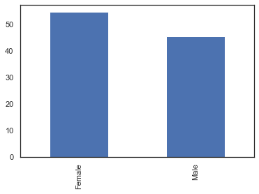

```python
dataset_byGender.plot(kind='bar')
```

#### 54.6%of the dataset are females and 45.4% are males

### AGE BAND

```python
re3  = df["GEN"].replace({1.0:"15<", 2.0: "15-19",3.0: "20-29",4.0: "30-39",5.0: "40-49",6.0: "50-59",7.0: "60>="}, inplace=True)
AgeB= df["GEN"].value_counts()

AgeB
```

```
50-59    93
40-49    93
30-39    68
60>=     61
20-29    51
15-19     2
Name: GEN, dtype: int64
```

```python
pen = df['GEN'].value_counts(ascending=False)*100/368
pen
```

```
50-59    25.271739
40-49    25.271739
30-39    18.478261
60>=     16.576087
20-29    13.858696
15-19     0.543478
Name: GEN, dtype: float64
```

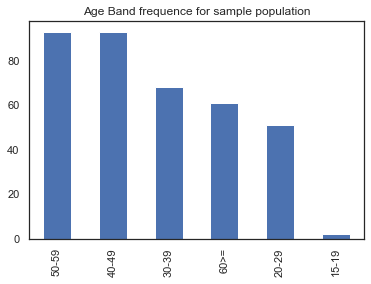

```python
#Age Band
AgeB.plot(kind='bar')
plt.title("Age Band frequence for sample population")
plt.show()
```

#### Most participants fall into age range of 40-49 and 50-59

### Prefecture

```python
re2  = df["PRE"].replace({1.0: "Hokkaido", 2.0: "Aomori",3.0: "Iwate",4.0: "Miyagi",5.0: "Akita",6.0: "Yamagata",7.0: "Fukushima",8.0: "Ibaragi",9.0: "Tochigi",10.0: "Gunma", 11.0:'Saitama', 12.0:'Chiba', 13.0:'Tokyo', 14.0:'Kanagawa', 15.0:'Niigata', 16.0:'Toyama', 17.0:'Ishikawa', 18.0:'Fukui', 19.0:'Yamanashi', 20.0:'Nagano', 21.0:'Gifu', 22.0:'Shizuoka', 23.0:'Aichi', 24.0:'Mie', 25.0:'Shiga',26.0:'Kyoto',27.0:'Osaka',28.0:'Hyogo',29.0:'Nara',30.0:'Wakayama',31.0:'Tottori',32.0:'Shimane',33.0:'Okayama',34.0:'Hiroshima',35.0:'Yamaguchi',36.0:'Tokushima',37.0:'Kagawa',38.0:'Ehime',39.0:'Kouchi',40.0:'Fukuoka',41.0:'Saga',42.0:'Nagasaki',43.0:'Kumamoto',44.0:'Oita',45.0:'Miyazaki',46.0:'Kagoshima',47.0:'Okinawa' }, inplace=True)
series2 = df["PRE"].value_counts()
series2
```

```
Tokyo        48
Kanagawa     36
Osaka        36
Aichi        32
Saitama      19
Hyogo        18
Fukuoka      15
Hokkaido     15
Chiba        14
Gunma         9
Yamaguchi     8
Kyoto         8
Niigata       8
Hiroshima     8
Miyagi        8
Okayama       8
Ibaragi       7
Shiga         6
Shizuoka      5
Oita          5
Mie           4
Tochigi       4
Kumamoto      4
Fukushima     4
Gifu          3
Nara          3
Ehime         3
Okinawa       3
Nagasaki      2
Kagoshima     2
Toyama        2
Tottori       2
Yamagata      2
Shimane       2
Tokushima     2
Akita         2
Wakayama      2
Yamanashi     2
Aomori        1
Saga          1
Nagano        1
Kouchi        1
Iwate         1
Ishikawa      1
Fukui         1
Name: PRE, dtype: int64
```

```python
pen1 = df['PRE'].value_counts(ascending=False)*100/368
pen1
```

```
Tokyo        13.043478
Kanagawa      9.782609
Osaka         9.782609
Aichi         8.695652
Saitama       5.163043
Hyogo         4.891304
Fukuoka       4.076087
Hokkaido      4.076087
Chiba         3.804348
Gunma         2.445652
Yamaguchi     2.173913
Kyoto         2.173913
Niigata       2.173913
Hiroshima     2.173913
Miyagi        2.173913
Okayama       2.173913
Ibaragi       1.902174
Shiga         1.630435
Shizuoka      1.358696
Oita          1.358696
Mie           1.086957
Tochigi       1.086957
Kumamoto      1.086957
Fukushima     1.086957
Gifu          0.815217
Nara          0.815217
Ehime         0.815217
Okinawa       0.815217
Nagasaki      0.543478
Kagoshima     0.543478
Toyama        0.543478
Tottori       0.543478
Yamagata      0.543478
Shimane       0.543478
Tokushima     0.543478
Akita         0.543478
Wakayama      0.543478
Yamanashi     0.543478
Aomori        0.271739
Saga          0.271739
Nagano        0.271739
Kouchi        0.271739
Iwate         0.271739
Ishikawa      0.271739
Fukui         0.271739
Name: PRE, dtype: float64
```

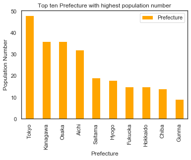

```python
k = series2.head(10)
k.plot(kind='bar',color='orange', label='Prefecture')
plt.title("Top ten Prefecture with highest population number")
plt.xlabel("Prefecture")
plt.ylabel("Population Number")
plt.legend()
plt.show()
```

### Dataset by Region

```python
re3  = df["ARE"].replace({1.0: "Hokkaido", 2.0: "Tohoku",3.0: "Kanto",4.0: "Chubu",5.0: "Kinki",6.0: "Chugoku",7.0: "Shikoku",8.0: "Kyushu"}, inplace=True)
series3 = df["ARE"].value_counts()
series3
```

```
Kanto       137
Kinki        77
Chubu        55
Kyushu       32
Chugoku      28
Tohoku       18
Hokkaido     15
Shikoku       6
Name: ARE, dtype: int64
```

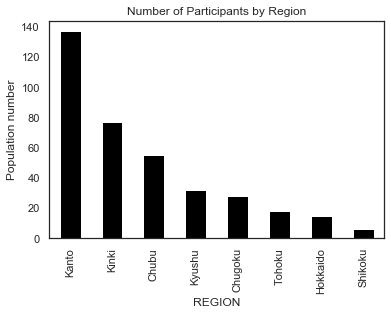

```python
series3.plot(kind='bar',color='black')
plt.title("Number of Participants by Region")
plt.xlabel("REGION")
plt.ylabel("Population number")
plt.show()
```

#### The highest number of participants is from Kanto Region

### Exploring Occupation

```python
#df['JOB'].astype(str)
re4  = df["JOB"].replace({1.0: "Civil-Servant", 2.0: "Exective",3.0: "Employee(Office based work)",4.0: "Employee(Manual work)",5.0: "Employee(Others)",6.0: "Self-employed",7.0: "Freelancer",8.0: "Housewife",9.0: "Part Time",10.0: "student", 11.0:'Others'}, inplace=True)
series4 = df["JOB"].value_counts()
series4
```

```
Part Time                      64
Employee(Office based work)    61
Housewife                      57
Employee(Others)               57
Employee(Manual work)          40
Others                         36
Self-employed                  18
student                        14
Civil-Servant                   9
Exective                        6
Freelancer                      6
Name: JOB, dtype: int64
```

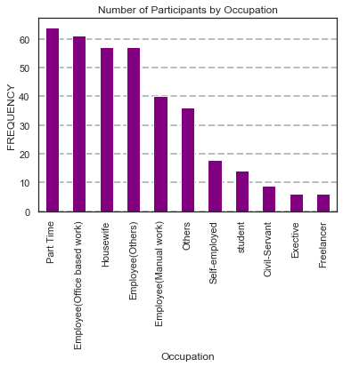

```python
series4.plot(kind='bar', color='purple')
plt.title("Number of Participants by Occupation")
plt.xlabel("Occupation")
plt.ylabel("FREQUENCY")
plt.grid(color='#95a5a6', linestyle='--', linewidth=2, axis='y', alpha=0.7)
plt.show()
```

### Marital Status

```python
re5 = df["MAR"].replace({1.0: "Single", 2.0: "Married"}, inplace=True)
```

```python
#Dataset by Marital Status in percentage
dataset_byMaritalStatus = df['MAR'].value_counts(ascending=False)*100/368
dataset_byMaritalStatus
```

```
Married    61.141304
Single     38.858696
Name: MAR, dtype: float64
```

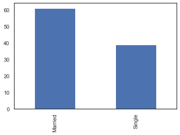

```python
dataset_byMaritalStatus.plot(kind='bar')
```

### Total number of participants with kids and no kid

```python
re6 = df["CHI"].replace({1.0: "Kids", 2.0: "No Kids"}, inplace=True)
dataset_byKids = df['CHI'].value_counts(ascending=False)*100/368
dataset_byKids
```

```
Kids       52.717391
No Kids    47.282609
Name: CHI, dtype: float64
```

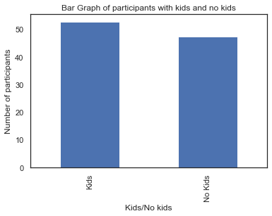

```python
ax  = dataset_byKids.plot(kind='bar')
ax.set_title("Bar Graph of participants with kids and no kids", y=1)
ax.set_xlabel('Kids/No kids')
ax.set_ylabel('Number of participants')
```

### MOBILE OS VERSION

```python
z= df["q2c1"].value_counts()
y= df["q2c2"].value_counts()
x= df["q2c3"].value_counts()
w= df["q2c4"].value_counts()
w
```

```
0.0    366
1.0      2
Name: q2c4, dtype: int64
```

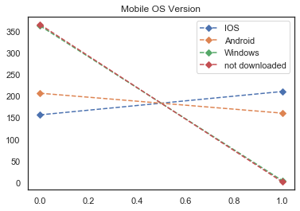

```python
x=[0,1]
q2c1=[157,211]
q2c2=[207,161]
q2c3=[363,5]
q2c4=[366,2]
plt.plot(x,q2c1, linestyle= 'dashed', marker='D', label='IOS')
plt.plot(x,q2c2, linestyle= 'dashed', marker='D', label='Android' )
plt.plot(x,q2c3, linestyle= 'dashed', marker='D', label='Windows' )
plt.plot(x,q2c4, linestyle= 'dashed', marker='D', label='not downloaded' )
plt.title("Mobile OS Version")
plt.legend()
plt.show()
```

### DIFFERENT USE OF THE APPLICATION

```python
diffU  = df["q3"].replace({1.0: "Education", 2.0: "Monitoring",3.0: "Fitness",4.0: "Diagnosis",5.0: "Treatment",6.0: "Other"}, inplace=True)
sdiffU = df["q3"].value_counts()
sdiffU
```

```
Monitoring    123
Fitness        73
Other          65
Diagnosis      52
Education      48
Treatment       7
Name: q3, dtype: int64
```

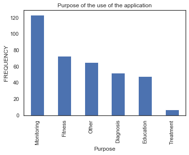

```python
sdiffU.plot(kind='bar')
plt.title("Purpose of the use of the application")
plt.xlabel("Purpose")
plt.ylabel("FREQUENCY")
plt.show()
```

```python
 Usepercent= df['q3'].value_counts(ascending=False)*100/368
 Usepercent
```

```
Monitoring    33.423913
Fitness       19.836957
Other         17.663043
Diagnosis     14.130435
Education     13.043478
Treatment      1.902174
Name: q3, dtype: float64
```

#### 33.4% of the participants used it for Monitoring, 19.8% used it for Fitness, 14.1% used it for diagnosis, 13% used it for Education, 1.9% used it for Treatment and 17.7% used it for other purpose.

### ENGAGEMENT -is the app entertaining ?

```python
f= df["q4s2"].value_counts()
f
```

```
2.0    122
3.0    108
4.0     76
5.0     31
1.0     31
Name: q4s2, dtype: int64
```

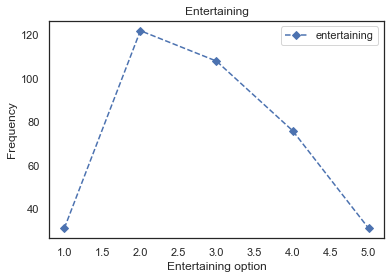

```python
x= [1.0,2.0,3.0,4.0,5.0]
q4s2=[31,122,108,76,31]
plt.plot(x,q4s2, linestyle= 'dashed', marker='D', label='entertaining')
plt.title("Entertaining")
plt.ylabel('Frequency')
plt.xlabel('Entertaining option')
plt.legend()
plt.show()
```

#### The analysis shows that 31 participants strongly agreed that the application is entertaining, 122 participants agreed, 108 have not decided, 76 disagree and 31 strongly disagree. The number of participants that agreed is much more, we can conclude that the application is entertaining.

### FUNCTIONALITY - Performance, Ease of use and Navigation.

```python
#Functionality
b= df["q4s3"].value_counts()
c= df["q4s4"].value_counts()
d= df["q4s5"].value_counts()
c
```

```
2.0    179
3.0    104
4.0     38
1.0     34
5.0     13
Name: q4s4, dtype: int64
```

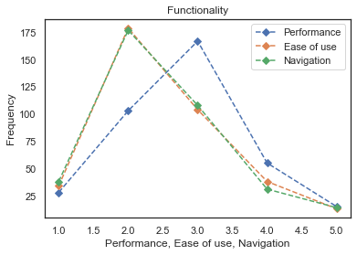

```python
x= [1.0,2.0,3.0,4.0,5.0]# 1 stands for strongly agree, agree, not decided, disagree and strongly disagree.
q4s3=[28,103,167,55,15]
q4s4=[34,179,104,38,13]
q4s5=[38,177,108,31,14]
plt.plot(x,q4s3, linestyle= 'dashed', marker='D', label='Performance')
plt.plot(x,q4s4, linestyle= 'dashed', marker='D',label='Ease of use' )
plt.plot(x,q4s5, linestyle= 'dashed', marker='D',label='Navigation' )
plt.title("Functionality")
plt.ylabel('Frequency')
plt.xlabel('Performance, Ease of use, Navigation')
plt.legend()
plt.show()
#q4s3 is for performance, q4s4 is for Ease of use and q4s5 is for navigation
```

#### The application is easy to use and navigate

### AESTHETICS - Layout, Graphics, Visual Appeal

```python
#AESTHETICS
g= df["q4s6"].value_counts()
h= df["q4s7"].value_counts()
i= df["q4s8"].value_counts()
i
```

```
2.0    154
3.0    130
4.0     38
1.0     35
5.0     11
Name: q4s8, dtype: int64
```

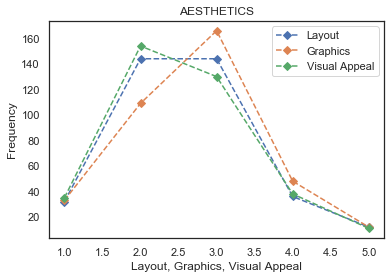

```python
x= [1.0,2.0,3.0,4.0,5.0]# 1 stands for strongly agree, agree, not decided, disagree and strongly disagree.
q4s6=[32,144,144,36,12]
q4s7=[33,109,166,48,12]
q4s8=[35,154,130,38,11]
plt.plot(x,q4s6, linestyle= 'dashed', marker='D', label='Layout')
plt.plot(x,q4s7, linestyle= 'dashed', marker='D',label='Graphics' )
plt.plot(x,q4s8, linestyle= 'dashed', marker='D',label='Visual Appeal' )
plt.title("AESTHETICS")
plt.ylabel('Frequency')
plt.xlabel('Layout, Graphics, Visual Appeal')
plt.legend()
plt.show()
```

#### This analysis shows that the app looks good and have a good layout.

### PRIVACY, ETHICS and INFORMATION - Visual, Quality, Credibility, Confidentiality and privacy, ethical

```python
j= df["q4s9"].value_counts()
k= df["q4s10"].value_counts()
l= df["q4s11"].value_counts()
m= df["q4s12"].value_counts()
n= df["q4s13"].value_counts()
j
```

```
3.0    162
2.0    133
4.0     40
1.0     22
5.0     11
Name: q4s9, dtype: int64
```

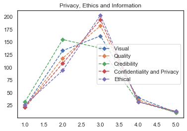

```python
q4s9=[22,133,162,40,11]
q4s10=[22,118,182,36,10]
q4s11=[32,155,138,32,11]
q4s12=[21,108,194,32,13]
q4s13=[26,94,203,32,13]
plt.plot(x,q4s9, linestyle= 'dashed', marker='D', label='Visual ')
plt.plot(x,q4s10, linestyle= 'dashed', marker='D',label='Quality' )
plt.plot(x,q4s11, linestyle= 'dashed', marker='D',label='Credibility' )
plt.plot(x,q4s12, linestyle= 'dashed', marker='D',label='Confidentiality and Privacy' )
plt.plot(x,q4s13, linestyle= 'dashed', marker='D',label='Ethical' )
plt.title("Privacy, Ethics and Information")
plt.legend()
plt.show()
```

#### Overall Rating

```python
o= df["q4s14"].value_counts()
p= df["q4s15"].value_counts()
o
```

```
2.0    158
3.0    143
1.0     32
4.0     24
5.0     11
Name: q4s14, dtype: int64
```

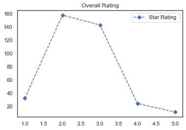

```python
x= [1.0,2.0,3.0,4.0,5.0]
q4s14=[32,158,143,24,11]
q4s15=[25,133,160,36,14]
plt.plot(x,q4s14, linestyle= 'dashed', marker='D', label='Star Rating ')
plt.title("Overall Rating")
plt.legend()
plt.show()
```

#### This analysis shows that the application is well rated and of good performance.

### Gender usage by Age

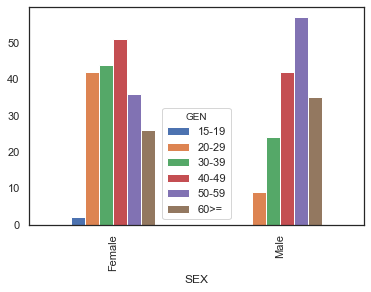

```python
data1 =  pd.DataFrame(df, columns= ['SEX','GEN'])
pd.crosstab(data1['SEX'],data1['GEN']).plot.bar()
```

#### Most male participants that used the application fall into the age range of 50-59 and most female participants that used the application fall into the age range of 40-49

### Purpose and Operating System(s)

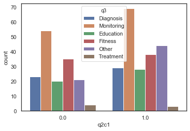

```python
# IOS operating system
sns.countplot(x="q2c1", hue='q3', data=df)
plt.show()
```

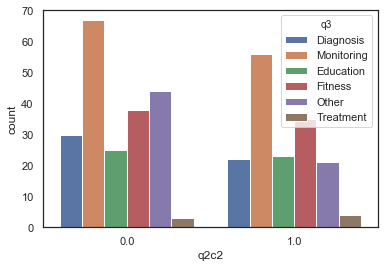

```python
# Android operating system
sns.countplot(x="q2c2", hue='q3', data=df)
plt.show()
```

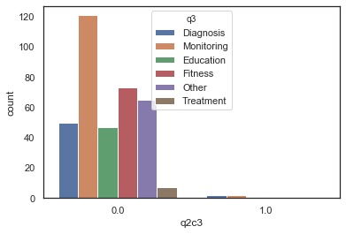

```python
# Windows operating system
sns.countplot(x="q2c3", hue='q3', data=df)
plt.show()
```

## Purpose with Age Band and Gender

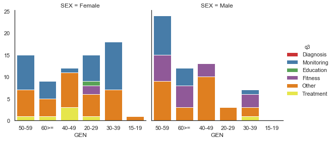

```python
fig =sns.FacetGrid(data=df,col='SEX',hue='q3',palette='Set1',size=4,aspect=1).map(sns.countplot,'GEN',order=df.GEN.unique()).add_legend()
```

### Rating based on gender usage and Age

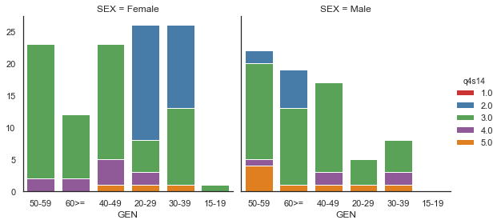

```python
fig =sns.FacetGrid(data=df,col='SEX',hue='q4s14',palette='Set1',size=4,aspect=1).map(sns.countplot,'GEN',order=df.GEN.unique()).add_legend()
```

### Rating based on Gender usage and Marital Status

```python
sns.set_style('white')
```

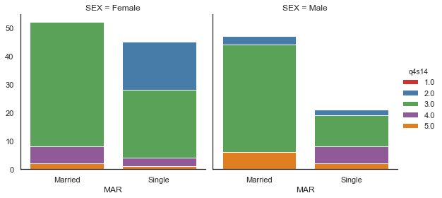

```python
fig =sns.FacetGrid(data=df,col='SEX',hue='q4s14',palette='Set1',size=4,aspect=1).map(sns.countplot,'MAR',order=df.MAR.unique()).add_legend()
```

### Operating system(s) based on Age and Gender

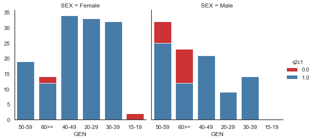

```python
#IOS operating system
fig =sns.FacetGrid(data=df,col='SEX',hue='q2c1',palette='Set1',size=4,aspect=1).map(sns.countplot,'GEN',order=df.GEN.unique()).add_legend()
```

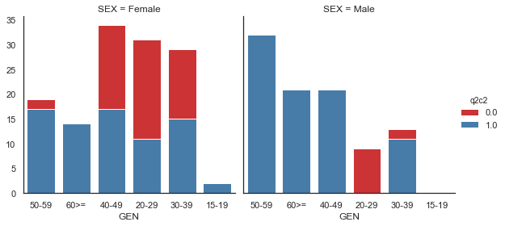

```python
#Android operating system
fig =sns.FacetGrid(data=df,col='SEX',hue='q2c2',palette='Set1',size=4,aspect=1).map(sns.countplot,'GEN',order=df.GEN.unique()).add_legend()
```

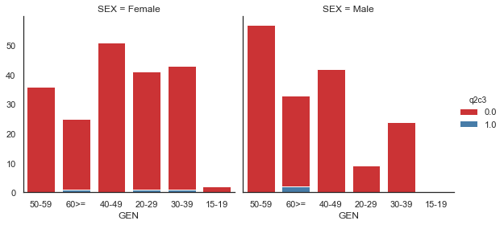

```python
#Windows operating system
fig =sns.FacetGrid(data=df,col='SEX',hue='q2c3',palette='Set1',size=4,aspect=1).map(sns.countplot,'GEN',order=df.GEN.unique()).add_legend()
```

### Purpose based on Age Band

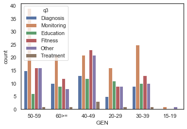

```python
sns.countplot(x="GEN", hue='q3', data=df)
plt.show()
```

### Rating of operating system versions based on Kids and Occupation.

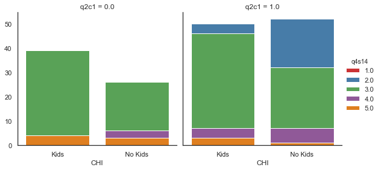

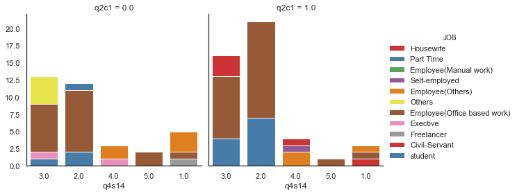

```python
#IOS(q2c1) Operating System Version
fig =sns.FacetGrid(data=df,col='q2c1',hue='q4s14',palette='Set1',size=4,aspect=1).map(sns.countplot,'CHI',order=df.CHI.unique()).add_legend()
fig =sns.FacetGrid(data=df,col='q2c1',hue='JOB',palette='Set1',size=4,aspect=1).map(sns.countplot,'q4s14',order=df.q4s14.unique()).add_legend()
```

#### Most Participants with no kids make use of the IOS operating system version of the application especially Employees and part time workers

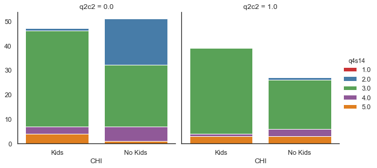

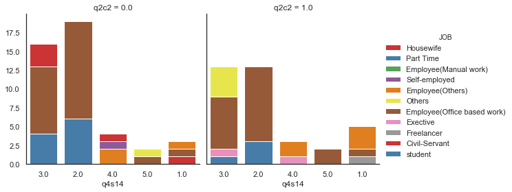

```python
#Android Operating System (q2c2) Version
fig =sns.FacetGrid(data=df,col='q2c2',hue='q4s14',palette='Set1',size=4,aspect=1).map(sns.countplot,'CHI',order=df.CHI.unique()).add_legend()
fig =sns.FacetGrid(data=df,col='q2c2',hue='JOB',palette='Set1',size=4,aspect=1).map(sns.countplot,'q4s14',order=df.q4s14.unique()).add_legend()
```

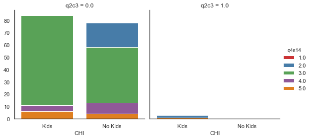

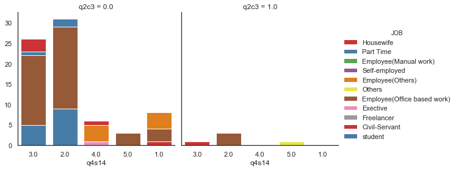

```python
#Windows Operating System Version
fig =sns.FacetGrid(data=df,col='q2c3',hue='q4s14',palette='Set1',size=4,aspect=1).map(sns.countplot,'CHI',order=df.CHI.unique()).add_legend()
fig =sns.FacetGrid(data=df,col='q2c3',hue='JOB',palette='Set1',size=4,aspect=1).map(sns.countplot,'q4s14',order=df.q4s14.unique()).add_legend()
```

#### House wife with kids and Employee(Office based work) with kids are the major users of the windows version of the application.